# Tugas-Pertemuan-2

# Library/Packages

```r
library("forecast")
```

```r
library("graphics")
library("TTR")
library("TSA")
```

# Impor Data

```r
library(rio)
data3 <- import("C:/Users/nuran/OneDrive/Documents/Semester 5/MPDW/mpdw/Pertemuan-2/Beijing_Air_Quality_Rapi.csv")
data3 <- data3[1:194, ]
# menampilkan 5 data pertama
head(data3)
```

```
##   Periode Count
## 1       1   263
## 2       2   270
## 3       3   259
## 4       4   281
## 5       5   267
## 6       6   244
```

# Eksplorasi Data

`View()` : menampilkan data dalam bentuk tabel, `str()` : menampilkan struktur data, `dim()` : menampilkan dimensi data

```r
View(data3)
str(data3)
```

```
## 'data.frame':    194 obs. of  2 variables:
##  $ Periode: int  1 2 3 4 5 6 7 8 9 10 ...
##  $ Count  : int  263 270 259 281 267 244 258 286 288 280 ...
```

```r
dim(data3)
```

```
## [1] 194   2
```

## Mengubah data agar terbaca sebagai data deret waktu dengan fungsi `ts()` .

```r
data3.ts <- ts(data3$Count)
# Menampilkan ringkasan data
summary(data3.ts)
```

```
##    Min. 1st Qu.  Median    Mean 3rd Qu.    Max.
##   216.0   275.5   284.0   277.4   287.0   288.0
```

## Membuat plot data deret waktu

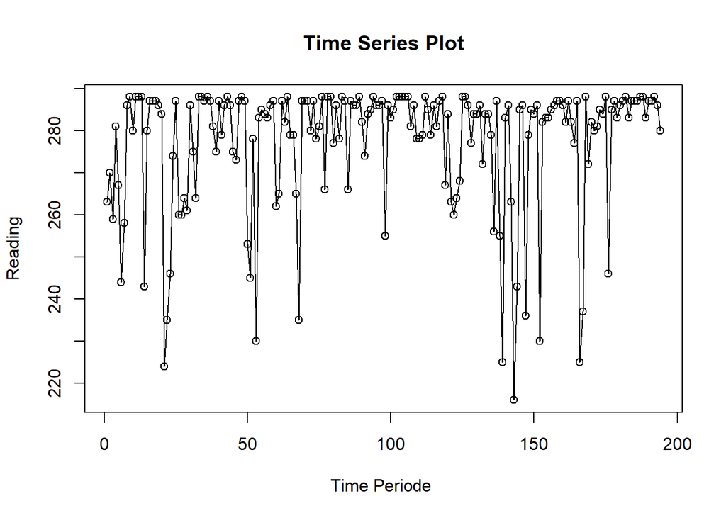

```r
ts.plot(data3.ts, xlab="Time Periode ", ylab="Reading",
        main = "Time Series Plot")
points(data3.ts)
```

```r
#menyimpan plot
dev.copy(png, "plot_data3.png")
```

```r
dev.off()
```

# Moving Average

## Pembagian Data

Pembagian data latih dan data uji dilakukan dengan perbandingan 80% data latih dan 20% data uji.

```r
# hitung jumlah data
n <- nrow(data3)

# tentukan batas 80%
n_train <- floor(0.8 * n)

# bagi data
training_ma <- data3[1:n_train, ]
testing_ma  <- data3[(n_train+1):n, ]

# ubah ke time series
train_ma.ts <- ts(training_ma$Count)
test_ma.ts  <- ts(testing_ma$Count)
```

## Eksplorasi data dilakukan pada keseluruhan data, data latih serta data uji menggunakan plot data deret waktu.

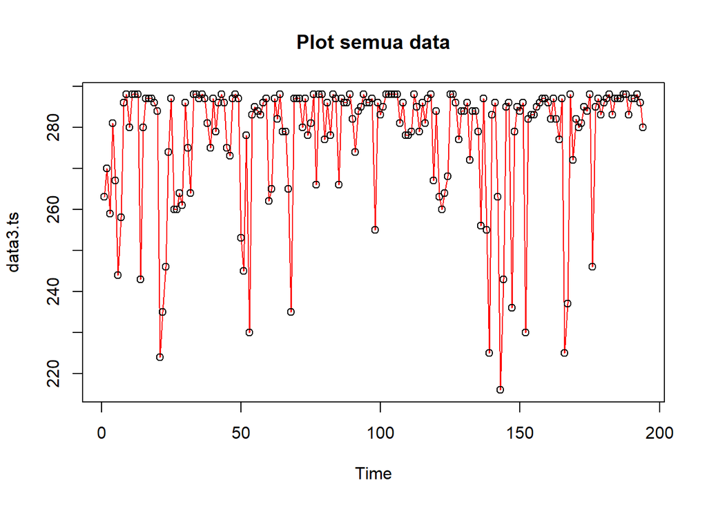

```r
#eksplorasi keseluruhan data
plot(data3.ts, col="red",main="Plot semua data")
points(data3.ts)
```

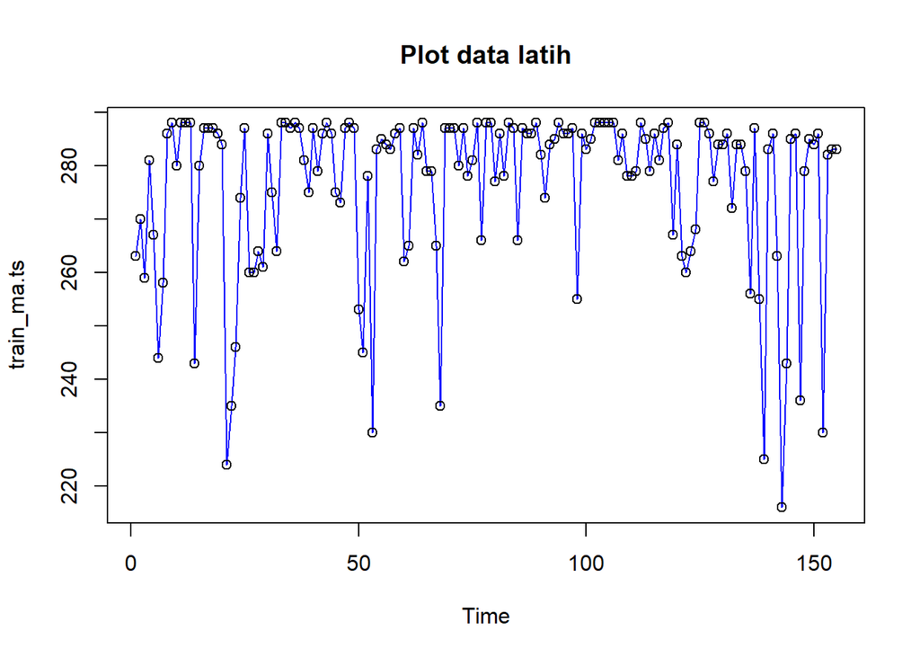

```r
#eksplorasi data latih
plot(train_ma.ts, col="blue",main="Plot data latih")
points(train_ma.ts)
```

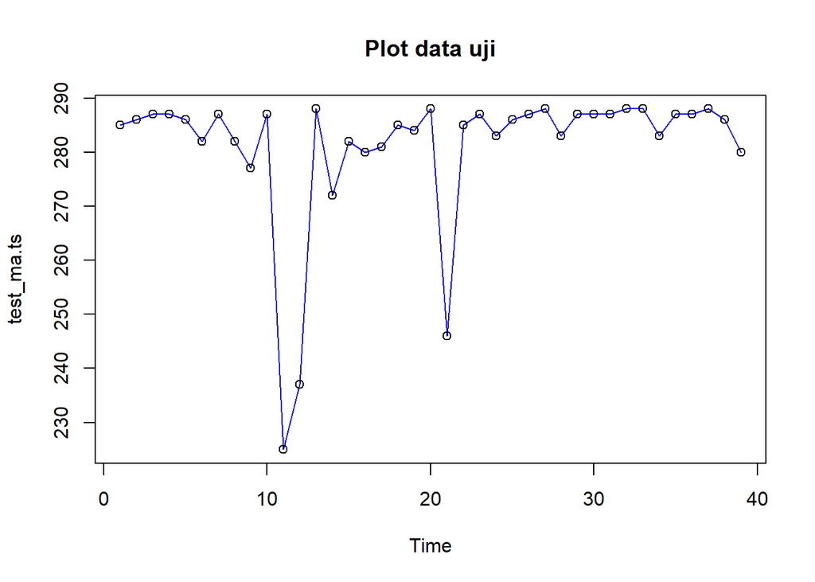

```r
#eksplorasi data uji
plot(test_ma.ts, col="blue",main="Plot data uji")
points(test_ma.ts)
```

## Eksplorasi data juga dapat dilakukan menggunakan package `ggplot2` dengan terlebih dahulu memanggil library *package* `ggplot2`.

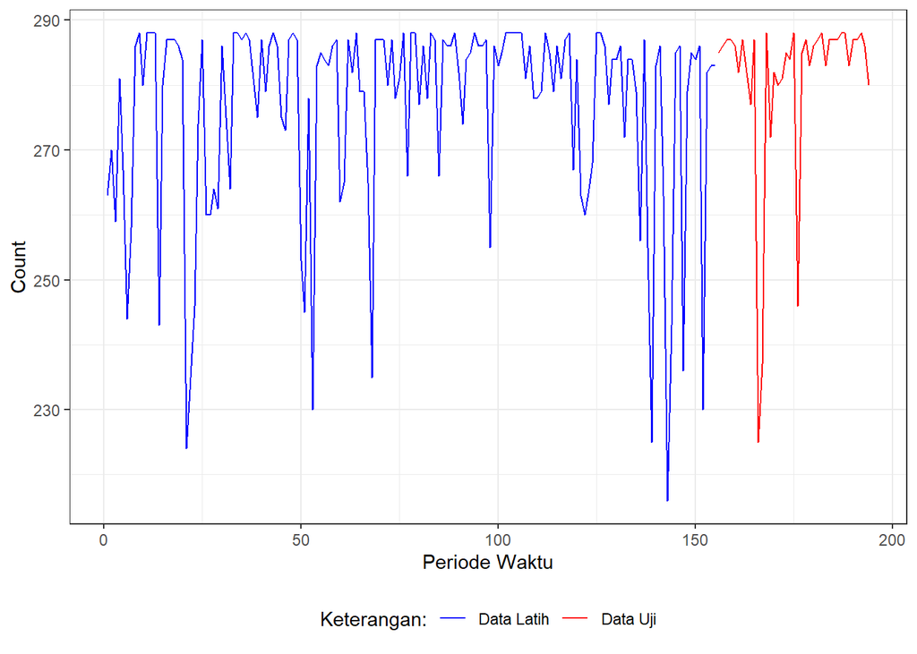

```r
library(ggplot2)
ggplot() +
  geom_line(data = training_ma, aes(x = Periode, y = Count, col = "Data Latih")) +
  geom_line(data = testing_ma, aes(x = Periode, y = Count, col = "Data Uji")) +
  labs(x = "Periode Waktu", y = "Count", color = "Legend") +
   scale_colour_manual(name="Keterangan:", breaks = c("Data Latih", "Data Uji"),
                      values = c("blue", "red")) +
  theme_bw() + theme(legend.position = "bottom",
                     plot.caption = element_text(hjust=0.5, size=12))
```

# Single Moving Average Pemulusan menggunakan metode SMA dilakukan dengan fungsi `SMA()`. Dalam hal ini akan dilakukan pemulusan dengan parameter `m=4`.

```r
data.sma<-SMA(train_ma.ts, n=4)
data.sma
```

```
## Time Series:
## Start = 1
## End = 155
## Frequency = 1
##   [1]     NA     NA     NA 268.25 269.25 262.75 262.50 263.75 269.00 278.00
##  [11] 285.50 286.00 286.00 276.75 274.75 274.50 274.25 285.25 286.75 286.00
##  [21] 270.25 257.25 247.25 244.75 260.50 266.75 270.25 267.75 261.25 267.75
##  [31] 271.50 271.50 278.25 278.75 281.75 287.75 287.50 285.75 282.75 282.50
##  [41] 280.50 281.75 285.00 284.75 283.75 280.50 280.25 280.75 283.75 278.75
##  [51] 268.25 265.75 251.50 259.00 269.00 270.50 283.75 284.50 285.00 279.50
##  [61] 275.00 275.25 274.00 280.50 284.00 282.00 277.75 264.50 266.50 268.50
##  [71] 274.00 285.25 285.25 283.00 281.50 283.50 278.25 280.75 282.50 279.75
##  [81] 284.75 282.25 282.25 284.75 279.75 282.00 281.50 281.25 286.75 285.50
##  [91] 282.50 282.00 281.25 282.75 285.75 286.25 286.75 278.50 278.50 277.75
## [101] 277.25 285.50 286.00 287.25 288.00 288.00 286.25 285.75 283.25 280.75
## [111] 280.25 280.75 282.50 282.75 284.50 282.75 283.25 285.50 280.75 281.50
## [121] 275.50 268.50 267.75 263.75 270.00 277.00 282.50 284.75 283.75 282.75
## [131] 282.75 281.50 281.50 281.50 279.75 275.75 276.50 269.25 255.75 262.50
## [141] 262.25 264.25 262.00 252.00 251.75 257.50 262.50 271.50 271.50 271.00
## [151] 283.50 271.25 270.50 270.25 269.50
```

Data pemulusan pada periode ke-t selanjutnya digunakan sebagai nilai peramalan pada periode ke t+1 sehingga hasil peramalan 1 periode kedepan adalah sebagai berikut.

```r
data.ramal<-c(NA,data.sma)
data.ramal #forecast 1 periode ke depan
```

```
##   [1]     NA     NA     NA     NA 268.25 269.25 262.75 262.50 263.75 269.00
##  [11] 278.00 285.50 286.00 286.00 276.75 274.75 274.50 274.25 285.25 286.75
##  [21] 286.00 270.25 257.25 247.25 244.75 260.50 266.75 270.25 267.75 261.25
##  [31] 267.75 271.50 271.50 278.25 278.75 281.75 287.75 287.50 285.75 282.75
##  [41] 282.50 280.50 281.75 285.00 284.75 283.75 280.50 280.25 280.75 283.75
##  [51] 278.75 268.25 265.75 251.50 259.00 269.00 270.50 283.75 284.50 285.00
##  [61] 279.50 275.00 275.25 274.00 280.50 284.00 282.00 277.75 264.50 266.50
##  [71] 268.50 274.00 285.25 285.25 283.00 281.50 283.50 278.25 280.75 282.50
##  [81] 279.75 284.75 282.25 282.25 284.75 279.75 282.00 281.50 281.25 286.75
##  [91] 285.50 282.50 282.00 281.25 282.75 285.75 286.25 286.75 278.50 278.50
## [101] 277.75 277.25 285.50 286.00 287.25 288.00 288.00 286.25 285.75 283.25
## [111] 280.75 280.25 280.75 282.50 282.75 284.50 282.75 283.25 285.50 280.75
## [121] 281.50 275.50 268.50 267.75 263.75 270.00 277.00 282.50 284.75 283.75
## [131] 282.75 282.75 281.50 281.50 281.50 279.75 275.75 276.50 269.25 255.75
## [141] 262.50 262.25 264.25 262.00 252.00 251.75 257.50 262.50 271.50 271.50
## [151] 271.00 283.50 271.25 270.50 270.25 269.50
```

Selanjutnya dilakukan peramalan sebanyak 39 periode sesuai dengan jumlah data uji. Pada metode SMA, seluruh hasil peramalan untuk 39 periode ke depan akan memiliki nilai yang sama dengan hasil ramalan satu periode ke depan.

```r
data.gab<-cbind(
  aktual=c(data3.ts),
  pemulusan=c(data.sma,rep(NA,39)),
  ramalan=c(data.ramal,rep(data.ramal[length(data.ramal)],38)))

data.gab #forecast 39 periode ke depan
```

```
##        aktual pemulusan ramalan
##   [1,]    263        NA      NA
##   [2,]    270        NA      NA
##   [3,]    259        NA      NA
##   [4,]    281    268.25      NA
##   [5,]    267    269.25  268.25
##   [6,]    244    262.75  269.25
##   [7,]    258    262.50  262.75
##   [8,]    286    263.75  262.50
##   [9,]    288    269.00  263.75
##  [10,]    280    278.00  269.00
##  [11,]    288    285.50  278.00
##  [12,]    288    286.00  285.50
##  [13,]    288    286.00  286.00
##  [14,]    243    276.75  286.00
```

[output cut: 180 more lines]

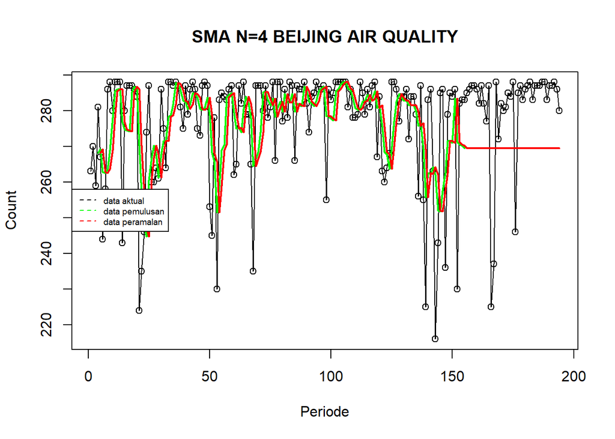

```r
# Plot SMA
ts.plot(data3.ts, xlab="Periode", ylab="Count", main= "SMA N=4 BEIJING AIR QUALITY")
points(data3.ts)
lines(data.gab[,2], col="green", lwd=2)
lines(data.gab[,3], col="red", lwd=2)
legend("left", c("data aktual", "data pemulusan", "data peramalan"), lty=8, col=c("black","green","red"), cex=0.6)
```

## Akurasi Data Latih

```r
#Menghitung nilai keakuratan data latih
error_train.sma = train_ma.ts-data.ramal[1:length(train_ma.ts)]

SSE_train.sma = sum(error_train.sma[5:length(train_ma.ts)]^2)
MSE_train.sma = mean(error_train.sma[5:length(train_ma.ts)]^2)
MAPE_train.sma = mean(abs((error_train.sma[5:length(train_ma.ts)]/train_ma.ts[5:length(train_ma.ts)])*100))

akurasi_train.sma <- matrix(c(SSE_train.sma, MSE_train.sma, MAPE_train.sma))
row.names(akurasi_train.sma)<- c("SSE", "MSE", "MAPE")
colnames(akurasi_train.sma) <- c("Akurasi m = 4")
akurasi_train.sma
```

```
##      Akurasi m = 4
## SSE   43181.312500
## MSE     285.968957
## MAPE      4.557897
```

Dalam hal ini, nilai MAPE data latih pada metode pemulusan SMA dengan parameter $n=4$ sebesar sekitar 4,56%. Nilai tersebut dapat dikategorikan sebagai tingkat akurasi yang sangat baik. Selanjutnya, dilakukan perhitungan nilai MAPE data uji pada metode pemulusan SMA.

## Akurasi Data Uji

```r
#Menghitung nilai keakuratan data uji
error_test.sma <- test_ma.ts - data.gab[156:194, 3]

SSE_test.sma = sum(error_test.sma^2)
MSE_test.sma = mean(error_test.sma^2)
MAPE_test.sma = mean(abs((error_test.sma/test_ma.ts*100)))

akurasi_test.sma <- matrix(c(SSE_test.sma, MSE_test.sma, MAPE_test.sma))
row.names(akurasi_test.sma)<- c("SSE", "MSE", "MAPE")
colnames(akurasi_test.sma) <- c("Akurasi m = 4")
akurasi_test.sma
```

```
##      Akurasi m = 4
## SSE   12461.750000
## MSE     319.532051
## MAPE      6.050896
```

Perhitungan akurasi menggunakan data latih menghasilkan nilai MAPE yang kurang dari 10% sehingga nilai akurasi ini dapat dikategorikan sebagai sangat baik.

# Double Moving Average (DMA)

```r
dma <- SMA(data.sma, n = 4)
At <- 2*data.sma - dma
Bt <- 2/(4-1)*(data.sma - dma)
data.dma<- At+Bt
data.ramal3<- c(NA, data.dma)

t = 1:39
f = c()

for (i in t) {
  f[i] = At[length(At)] + Bt[length(Bt)]*(i)
}

data.gab2 <- cbind(aktual = c(data3.ts),
                   pemulusan1 = c(data.sma,rep(NA,39)),
                   pemulusan2 = c(dma, rep(NA,39)),
                   At = c(At, rep(NA,39)),
                   Bt = c(Bt,rep(NA,39)),
                   ramalan = c(data.ramal3, f[-1]))
data.gab2
```

```
##        aktual pemulusan1 pemulusan2       At           Bt  ramalan
##   [1,]    263         NA         NA       NA           NA       NA
##   [2,]    270         NA         NA       NA           NA       NA
##   [3,]    259         NA         NA       NA           NA       NA
##   [4,]    281     268.25         NA       NA           NA       NA
##   [5,]    267     269.25         NA       NA           NA       NA
##   [6,]    244     262.75         NA       NA           NA       NA
##   [7,]    258     262.50   265.6875 259.3125  -2.12500000       NA
##   [8,]    286     263.75   264.5625 262.9375  -0.54166667 257.1875
##   [9,]    288     269.00   264.5000 273.5000   3.00000000 262.3958
##  [10,]    280     278.00   268.3125 287.6875   6.45833333 276.5000
##  [11,]    288     285.50   274.0625 296.9375   7.62500000 294.1458
##  [12,]    288     286.00   279.6250 292.3750   4.25000000 304.5625
##  [13,]    288     286.00   283.8750 288.1250   1.41666667 296.6250
##  [14,]    243     276.75   283.5625 269.9375  -4.54166667 289.5417
```

[output cut: 180 more lines]

Hasil pemulusan menggunakan metode DMA divisualisasikan sebagai berikut

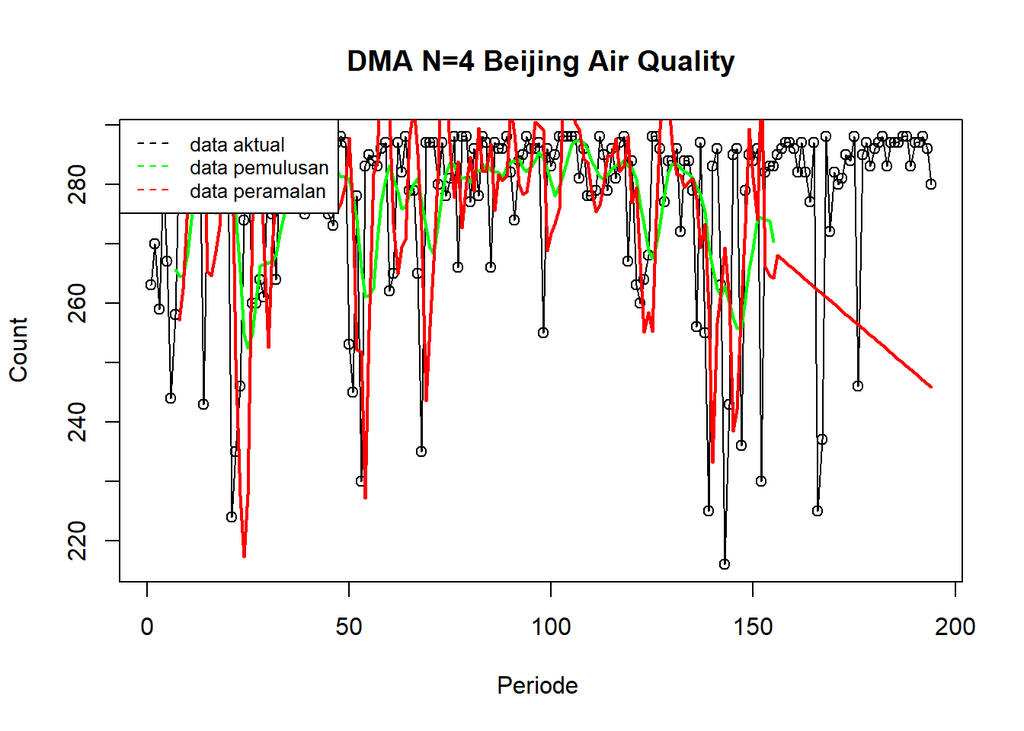

```r
ts.plot(data3.ts, xlab="Periode ", ylab="Count", main= "DMA N=4 Beijing Air Quality")
points(data3.ts)
lines(data.gab2[,3],col="green",lwd=2)
lines(data.gab2[,6],col="red",lwd=2)
legend("topleft",c("data aktual","data pemulusan","data peramalan"), lty=8, col=c("black","green","red"), cex=0.8)
```

## Akurasi Data Latih

```r
#Menghitung nilai keakuratan data latih
error_train.dma = train_ma.ts-data.ramal3[1:length(train_ma.ts)]

SSE_train.dma = sum(error_train.dma[8:length(train_ma.ts)]^2)
MSE_train.dma = mean(error_train.dma[8:length(train_ma.ts)]^2)
MAPE_train.dma = mean(abs((error_train.dma[8:length(train_ma.ts)]/train_ma.ts[8:length(train_ma.ts)])*100))

akurasi_train.dma <- matrix(c(SSE_train.dma, MSE_train.dma, MAPE_train.dma))
row.names(akurasi_train.dma)<- c("SSE", "MSE", "MAPE")
colnames(akurasi_train.dma) <- c("Akurasi m = 4")
akurasi_train.dma
```

```
##      Akurasi m = 4
## SSE   64081.187500
## MSE     432.980997
## MAPE      5.740993
```

Perhitungan akurasi pada data latih menggunakan nilai MAPE menghasilkan nilai MAPE yang kurang dari 10% sehingga dikategorikan sangat baik. Selanjutnya, perhitungan nilai akurasi dilakukan pada data uji.

## Akurasi Data Uji

```r
#Menghitung nilai keakuratan data uji
error_test.dma = test_ma.ts-data.gab2[156:194,6]
SSE_test.dma = sum(error_test.dma^2)
MSE_test.dma = mean(error_test.dma^2)
MAPE_test.dma = mean(abs((error_test.dma/test_ma.ts*100)))

akurasi_test.dma <- matrix(c(SSE_test.dma, MSE_test.dma, MAPE_test.dma))
row.names(akurasi_test.dma)<- c("SSE", "MSE", "MAPE")
colnames(akurasi_test.dma) <- c("Akurasi m = 4")
akurasi_test.dma
```

```
##      Akurasi m = 4
## SSE   32946.873264
## MSE     844.791622
## MAPE      9.889843
```

# Exponential Smoothing

## Pembagian Data

Pembagian data latih dan data uji dilakukan dengan perbandingan 80% data latih dan 20% data uji.

```r
# jumlah baris data
n <- nrow(data3)

# hitung batas 80%
n_train <- floor(0.8 * n)

# bagi data
training <- data3[1:n_train, ]
testing  <- data3[(n_train+1):n, ]

# ubah ke time series
train.ts <- ts(training$Count)
test.ts  <- ts(testing$Count)
```

## Eksplorasi

Eksplorasi dilakukan dengan membuat plot data deret waktu untuk keseluruhan data, data latih, dan data uji.

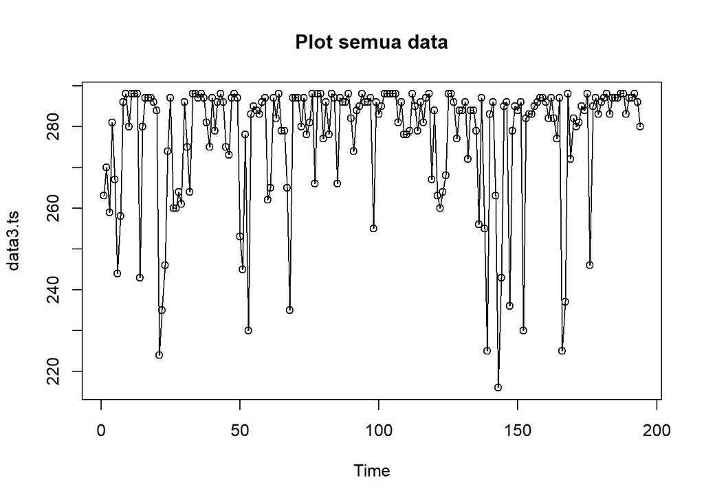

```r
#eksplorasi data
plot(data3.ts, col="black",main="Plot semua data")
points(data3.ts)
```

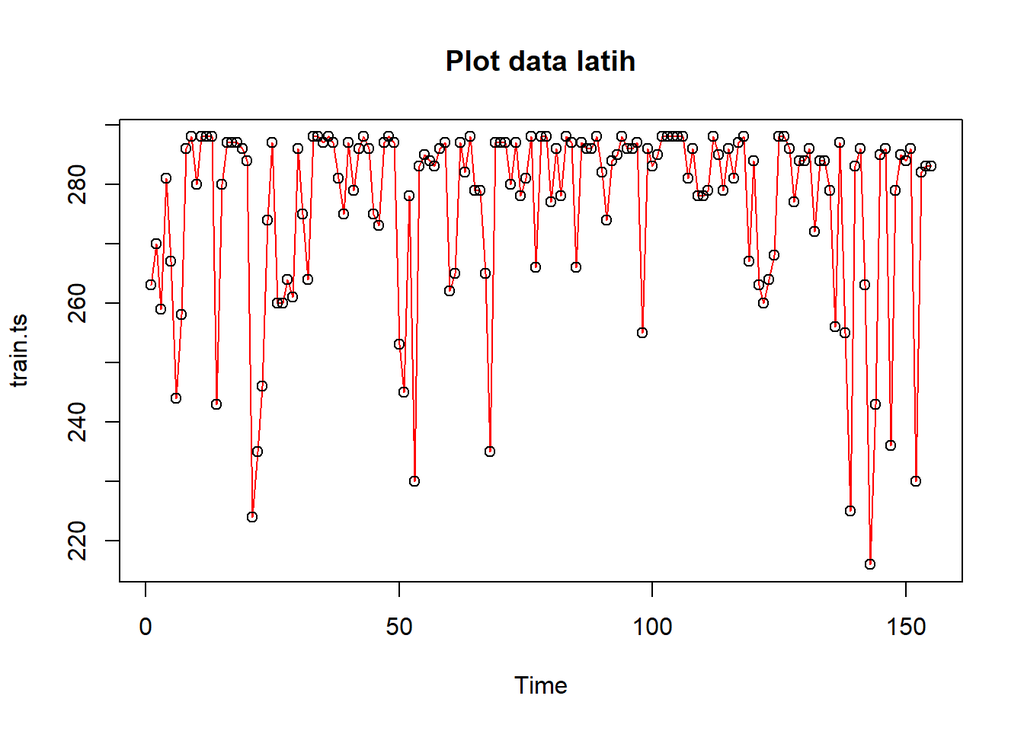

```r
plot(train.ts, col="red",main="Plot data latih")
points(train.ts)
```

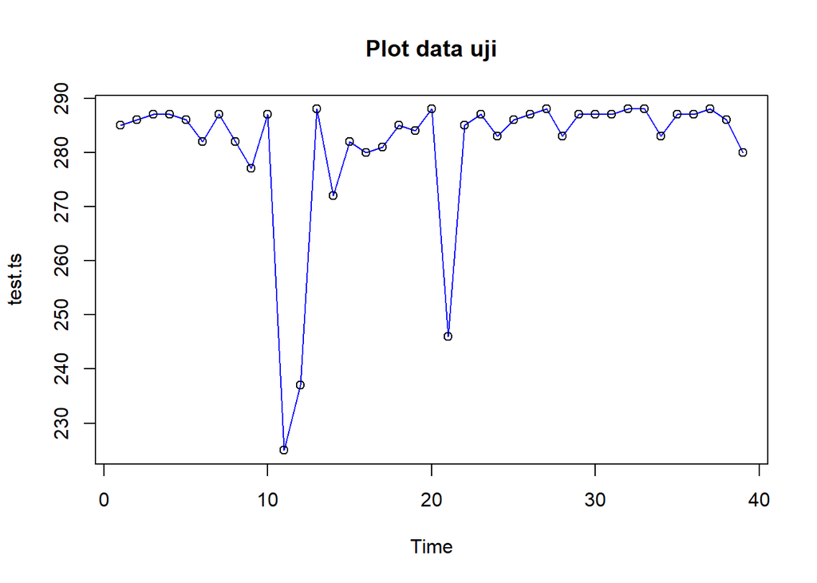

```r
plot(test.ts, col="blue",main="Plot data uji")
points(test.ts)
```

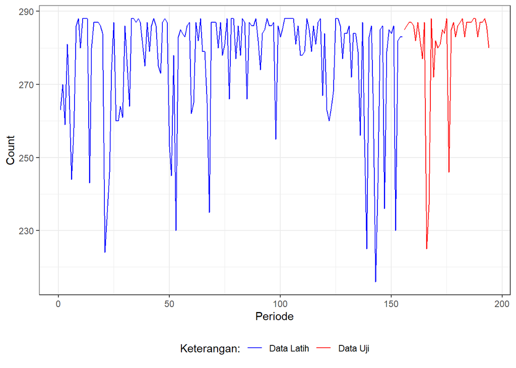

```r
#Eksplorasi dengan GGPLOT
library(ggplot2)
ggplot() +
  geom_line(data = training, aes(x = Periode, y = Count, col = "Data Latih")) +
  geom_line(data = testing, aes(x = Periode, y = Count, col = "Data Uji")) +
  labs(x = "Periode", y = "Count", color = "Legend") +
  scale_colour_manual(name="Keterangan:", breaks = c("Data Latih", "Data Uji"),
                      values = c("blue", "red")) +
  theme_bw() + theme(legend.position = "bottom",
                     plot.caption = element_text(hjust=0.5, size=12))
```

# Single Exponential Smoothing

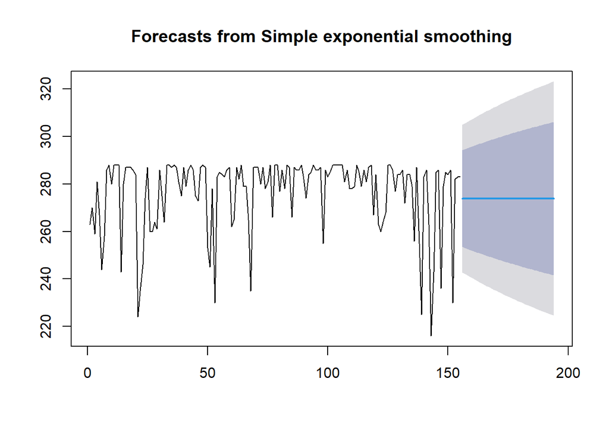

```r
#Cara 1 (fungsi ses)
ses.1 <- ses(train.ts, h = 39, alpha = 0.2)
plot(ses.1)
```

```r
ses.1
```

```
##     Point Forecast    Lo 80    Hi 80    Lo 95    Hi 95
## 156       273.8969 253.5665 294.2273 242.8042 304.9896
## 157       273.8969 253.1638 294.6299 242.1884 305.6053
## 158       273.8969 252.7689 295.0249 241.5844 306.2094
## 159       273.8969 252.3812 295.4126 240.9915 306.8023
## 160       273.8969 252.0004 295.7934 240.4090 307.3848
## 161       273.8969 251.6260 296.1678 239.8365 307.9572
## 162       273.8969 251.2579 296.5359 239.2735 308.5203
## 163       273.8969 250.8956 296.8981 238.7195 309.0743
## 164       273.8969 250.5390 297.2548 238.1741 309.6197
## 165       273.8969 250.1877 297.6060 237.6369 310.1569
## 166       273.8969 249.8416 297.9522 237.1075 310.6863
## 167       273.8969 249.5004 298.2934 236.5857 311.2081
## 168       273.8969 249.1639 298.6299 236.0710 311.7228
## 169       273.8969 248.8319 298.9619 235.5632 312.2305
```

[output cut: 25 more lines]

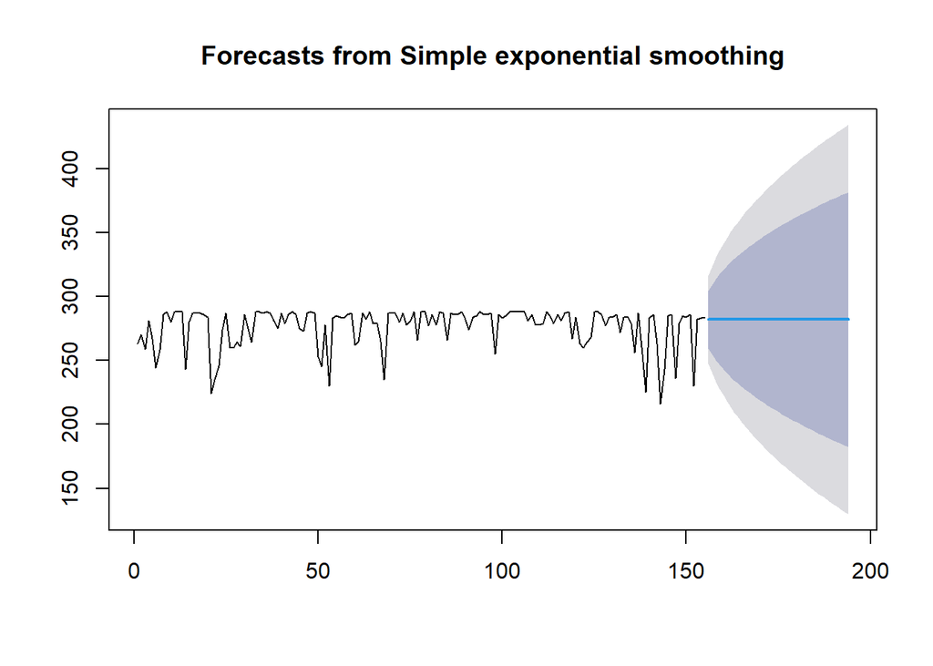

```r
ses.2<- ses(train.ts, h = 39, alpha = 0.7)
plot(ses.2)
```

```r
ses.2
```

```
##     Point Forecast    Lo 80    Hi 80    Lo 95    Hi 95
## 156       281.9522 259.4687 304.4358 247.5666 316.3378
## 157       281.9522 254.5076 309.3969 239.9793 323.9252
## 158       281.9522 250.3151 313.5894 233.5674 330.3371
## 159       281.9522 246.6166 317.2879 227.9110 335.9935
## 160       281.9522 243.2701 320.6344 222.7930 341.1115
## 161       281.9522 240.1909 323.7136 218.0838 345.8207
## 162       281.9522 237.3237 326.5808 213.6988 350.2057
## 163       281.9522 234.6299 329.2746 209.5789 354.3256
## 164       281.9522 232.0813 331.8231 205.6813 358.2232
## 165       281.9522 229.6569 334.2476 201.9734 361.9311
## 166       281.9522 227.3399 336.5646 198.4299 365.4746
## 167       281.9522 225.1173 338.7871 195.0308 368.8737
## 168       281.9522 222.9785 340.9260 191.7596 372.1448
## 169       281.9522 220.9145 342.9900 188.6031 375.3014
```

[output cut: 25 more lines]

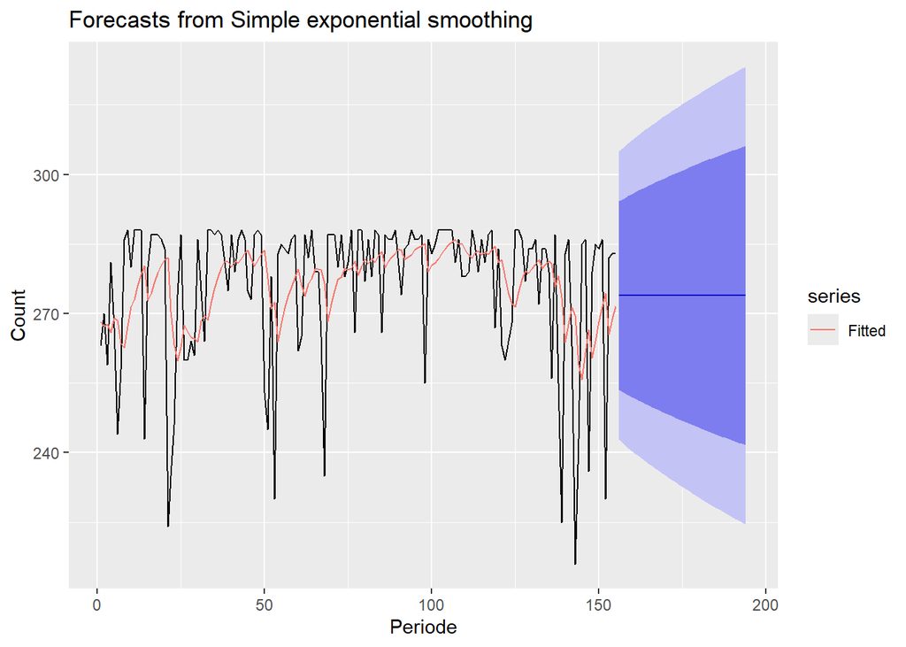

```r
autoplot(ses.1) +
  autolayer(fitted(ses.1), series="Fitted") +
  ylab("Count") + xlab("Periode")
```

Selanjutnya akan digunakan fungsi `HoltWinters()` dengan nilai inisialisasi parameter dan panjang periode peramalan yang sama dengan fungsi `ses()` .

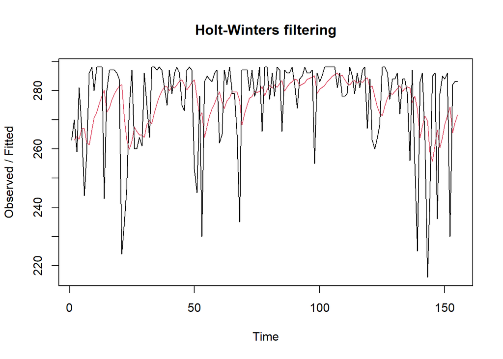

```r
#Cara 2 (fungsi Holtwinter)
ses1<- HoltWinters(train.ts, gamma = FALSE, beta = FALSE, alpha = 0.2)
plot(ses1)
```

```r
#ramalan
ramalan1<- forecast(ses1, h=39)
ramalan1
```

```
##     Point Forecast    Lo 80    Hi 80    Lo 95    Hi 95
## 156       273.8969 253.5516 294.2422 242.7814 305.0123
## 157       273.8969 253.1487 294.6451 242.1652 305.6286
## 158       273.8969 252.7534 295.0404 241.5608 306.2330
## 159       273.8969 252.3654 295.4283 240.9674 306.8264
## 160       273.8969 251.9843 295.8095 240.3845 307.4093
## 161       273.8969 251.6097 296.1841 239.8116 307.9822
## 162       273.8969 251.2413 296.5525 239.2482 308.5456
## 163       273.8969 250.8788 296.9150 238.6938 309.1000
## 164       273.8969 250.5219 297.2719 238.1480 309.6458
## 165       273.8969 250.1704 297.6234 237.6103 310.1834
## 166       273.8969 249.8240 297.9698 237.0806 310.7132
## 167       273.8969 249.4825 298.3113 236.5583 311.2354
## 168       273.8969 249.1458 298.6480 236.0433 311.7505
## 169       273.8969 248.8135 298.9803 235.5352 312.2586
```

[output cut: 25 more lines]

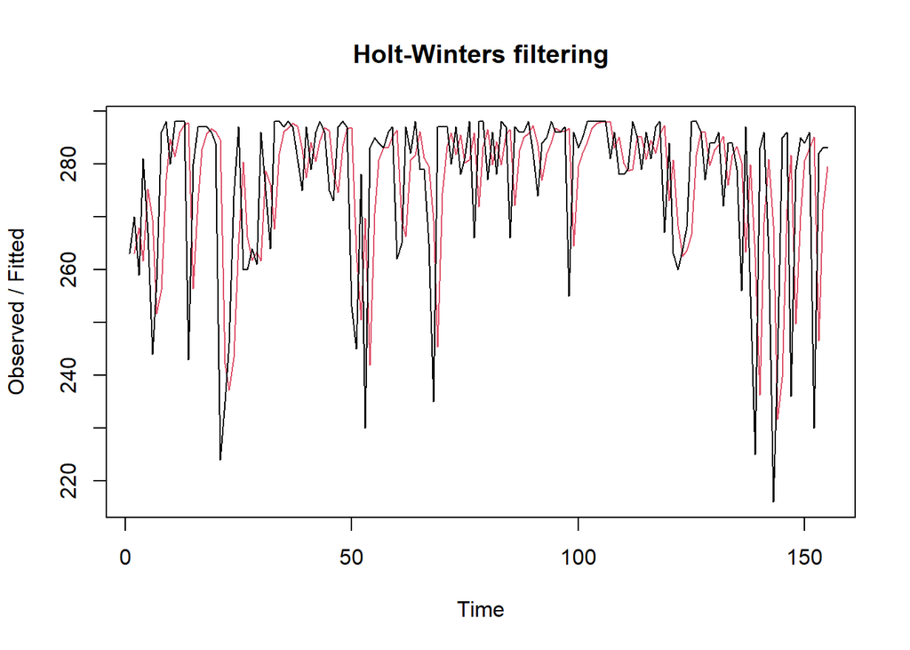

```r
ses2<- HoltWinters(train.ts, gamma = FALSE, beta = FALSE, alpha = 0.7)
plot(ses2)
```

```r
#ramalan
ramalan2<- forecast(ses2, h=39)
ramalan2
```

```
##     Point Forecast    Lo 80    Hi 80    Lo 95    Hi 95
## 156       281.9522 259.4692 304.4353 247.5674 316.3371
## 157       281.9522 254.5082 309.3963 239.9802 323.9243
## 158       281.9522 250.3158 313.5887 233.5685 330.3360
## 159       281.9522 246.6174 317.2871 227.9122 335.9922
## 160       281.9522 243.2710 320.6335 222.7943 341.1101
## 161       281.9522 240.1919 323.7126 218.0852 345.8192
## 162       281.9522 237.3247 326.5798 213.7003 350.2042
## 163       281.9522 234.6309 329.2735 209.5805 354.3239
## 164       281.9522 232.0825 331.8220 205.6830 358.2215
## 165       281.9522 229.6580 334.2464 201.9752 361.9293
## 166       281.9522 227.3411 336.5633 198.4318 365.4727
## 167       281.9522 225.1186 338.7859 195.0327 368.8718
## 168       281.9522 222.9798 340.9247 191.7617 372.1428
## 169       281.9522 220.9159 342.9886 188.6052 375.2993
```

[output cut: 25 more lines]

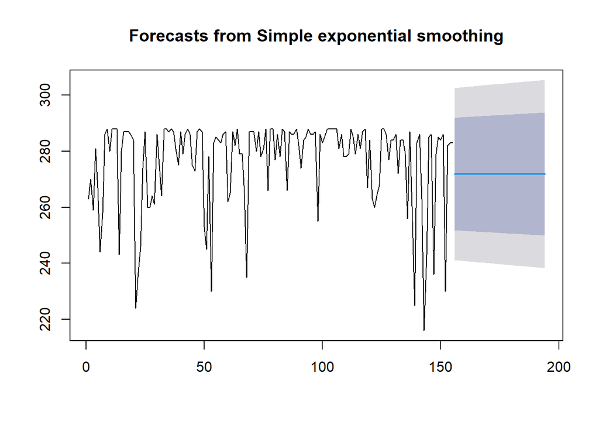

```r
#SES
ses.opt <- ses(train.ts, h = 39, alpha = NULL)
plot(ses.opt)
```

```r
ses.opt
```

```
##     Point Forecast    Lo 80    Hi 80    Lo 95    Hi 95
## 156       271.8319 251.7517 291.9121 241.1219 302.5419
## 157       271.8319 251.7011 291.9627 241.0444 302.6194
## 158       271.8319 251.6505 292.0133 240.9671 302.6967
## 159       271.8319 251.6001 292.0637 240.8900 302.7738
## 160       271.8319 251.5498 292.1140 240.8131 302.8507
## 161       271.8319 251.4996 292.1642 240.7364 302.9274
## 162       271.8319 251.4496 292.2142 240.6598 303.0040
## 163       271.8319 251.3996 292.2641 240.5835 303.0803
## 164       271.8319 251.3498 292.3140 240.5073 303.1565
## 165       271.8319 251.3002 292.3636 240.4313 303.2325
## 166       271.8319 251.2506 292.4132 240.3555 303.3083
## 167       271.8319 251.2012 292.4626 240.2799 303.3839
## 168       271.8319 251.1518 292.5120 240.2045 303.4593
## 169       271.8319 251.1026 292.5612 240.1292 303.5346
```

[output cut: 25 more lines]

```r
#Lamda Optimum Holt Winter
HWopt<- HoltWinters(train.ts, gamma = FALSE, beta = FALSE,alpha = NULL)
HWopt
```

```
## Holt-Winters exponential smoothing without trend and without seasonal component.
##
## Call:
## HoltWinters(x = train.ts, alpha = NULL, beta = FALSE, gamma = FALSE)
##
## Smoothing parameters:
##  alpha: 0.09771259
##  beta : FALSE
##  gamma: FALSE
##
## Coefficients:
##       [,1]
## a 271.6136
```

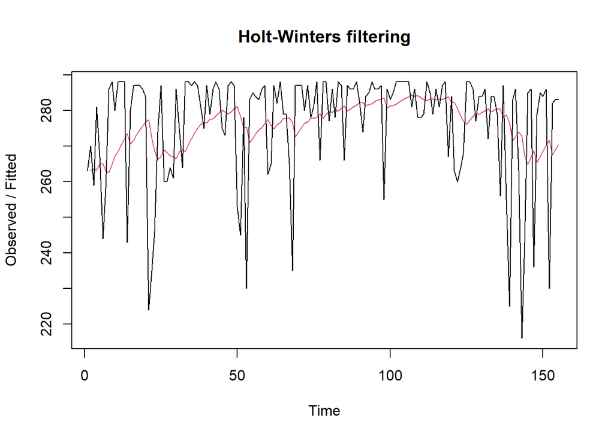

```r
plot(HWopt)
```

```r
#ramalan
ramalanopt<- forecast(HWopt, h=39)
ramalanopt
```

```
##     Point Forecast    Lo 80    Hi 80    Lo 95    Hi 95
## 156       271.6136 251.4384 291.7889 240.7582 302.4690
## 157       271.6136 251.3423 291.8850 240.6113 302.6160
## 158       271.6136 251.2466 291.9806 240.4650 302.7622
## 159       271.6136 251.1515 292.0758 240.3194 302.9078
## 160       271.6136 251.0567 292.1705 240.1745 303.0527
## 161       271.6136 250.9624 292.2648 240.0303 303.1969
## 162       271.6136 250.8685 292.3587 239.8867 303.3405
## 163       271.6136 250.7751 292.4522 239.7438 303.4835
## 164       271.6136 250.6820 292.5452 239.6015 303.6258
## 165       271.6136 250.5894 292.6379 239.4598 303.7674
## 166       271.6136 250.4972 292.7301 239.3188 303.9085
## 167       271.6136 250.4053 292.8219 239.1784 304.0489
## 168       271.6136 250.3139 292.9133 239.0385 304.1887
## 169       271.6136 250.2229 293.0044 238.8993 304.3279
```

[output cut: 25 more lines]

## Akurasi Data Latih

```r
#Keakuratan Metode
#Pada data training

# SES dengan alpha = 0.2
SSE1<-ses1$SSE
MSE1<-ses1$SSE/length(train.ts)
RMSE1<-sqrt(MSE1)

akurasi1 <- matrix(c(SSE1,MSE1,RMSE1))
row.names(akurasi1)<- c("SSE", "MSE", "RMSE")
colnames(akurasi1) <- c("Akurasi lamda=0.2")
akurasi1
```

```
##      Akurasi lamda=0.2
## SSE        38580.21817
## MSE          248.90463
## RMSE          15.77671
```

```r
# SES dengan alpha = 0.7
SSE2<-ses2$SSE
MSE2<-ses2$SSE/length(train.ts)
RMSE2<-sqrt(MSE2)

akurasi2 <- matrix(c(SSE2,MSE2,RMSE2))
row.names(akurasi2)<- c("SSE", "MSE", "RMSE")
colnames(akurasi2) <- c("Akurasi lamda=0.7")
akurasi2
```

```
##      Akurasi lamda=0.7
## SSE        47094.79914
## MSE          303.83741
## RMSE          17.43093
```

```r
#Cara Manual
# Alpha = 0.2
fitted1<-ramalan1$fitted
sisaan1<-ramalan1$residuals
head(sisaan1)
```

```
## Time Series:
## Start = 1
## End = 6
## Frequency = 1
## [1]       NA   7.0000  -5.4000  17.6800   0.1440 -22.8848
```

```r
resid1<-training$Count-ramalan1$fitted
head(resid1)
```

```
## Time Series:
## Start = 1
## End = 6
## Frequency = 1
## [1]       NA   7.0000  -5.4000  17.6800   0.1440 -22.8848
```

```r
SSE.1=sum(sisaan1[2:length(train.ts)]^2)
SSE.1
```

```
## [1] 38580.22
```

```r
MSE.1 = SSE.1/length(train.ts)
MSE.1
```

```
## [1] 248.9046
```

```r
MAPE.1 = sum(abs(sisaan1[2:length(train.ts)]/train.ts[2:length(train.ts)])*
               100)/length(train.ts)
MAPE.1
```

```
## [1] 4.365699
```

```r
akurasi.1 <- matrix(c(SSE.1,MSE.1,MAPE.1))
row.names(akurasi.1)<- c("SSE", "MSE", "MAPE")
colnames(akurasi.1) <- c("Akurasi lamda=0.2")
akurasi.1
```

```
##      Akurasi lamda=0.2
## SSE       38580.218174
## MSE         248.904633
## MAPE          4.365699
```

```r
# Alpha = 0.7
fitted2<-ramalan2$fitted
sisaan2<-ramalan2$residuals
head(sisaan2)
```

```
## Time Series:
## Start = 1
## End = 6
## Frequency = 1
## [1]       NA   7.0000  -8.9000  19.3300  -8.2010 -25.4603
```

```r
resid2<-training$Count-ramalan2$fitted
head(resid2)
```

```
## Time Series:
## Start = 1
## End = 6
## Frequency = 1
## [1]       NA   7.0000  -8.9000  19.3300  -8.2010 -25.4603
```

```r
SSE.2=sum(sisaan2[2:length(train.ts)]^2)
SSE.2
```

```
## [1] 47094.8
```

```r
MSE.2 = SSE.2/length(train.ts)
MSE.2
```

```
## [1] 303.8374
```

```r
MAPE.2 = sum(abs(sisaan2[2:length(train.ts)]/train.ts[2:length(train.ts)])*
               100)/length(train.ts)
MAPE.2
```

```
## [1] 4.440311
```

```r
akurasi.2 <- matrix(c(SSE.2,MSE.2,MAPE.2))
row.names(akurasi.2)<- c("SSE", "MSE", "MAPE")
colnames(akurasi.2) <- c("Akurasi lamda=0.7")
akurasi.2
```

```
##      Akurasi lamda=0.7
## SSE       47094.799137
## MSE         303.837414
## MAPE          4.440311
```

Berdasarkan nilai SSE, MSE, dan MAPE pada kedua parameter, nilai parameter $\lambda = 0,2$ menghasilkan tingkat akurasi yang lebih baik dibandingkan $\lambda = 0,7$. Hal ini ditunjukkan oleh nilai SSE sebesar 38.580,22, MSE sebesar 248,90, dan MAPE sebesar 4,37% pada $\lambda = 0,2$, yang seluruhnya lebih kecil dibandingkan dengan $\lambda = 0,7$, yaitu SSE sebesar 47.094,80, MSE sebesar 303,84, dan MAPE sebesar 4,44%. Berdasarkan nilai MAPE yang kurang dari 10%, hasil peramalan dengan parameter $\lambda = 0,2$ dapat dikategorikan memiliki tingkat akurasi yang sangat baik.

## Akurasi Data Uji

```r
# jumlah observasi uji
n_test <- nrow(testing)

# error (ramalan - aktual), samakan panjang dan tipe numeric
e1   <- as.numeric(ramalan1$mean)[1:n_test] - as.numeric(testing$Count)
e2   <- as.numeric(ramalan2$mean)[1:n_test] - as.numeric(testing$Count)
eopt <- as.numeric(ramalanopt$mean)[1:n_test] - as.numeric(testing$Count)

# SSE / MSE / RMSE untuk masing-masing model (abaikan NA)
SSEtesting1  <- sum(e1^2,  na.rm = TRUE)
MSEtesting1  <- mean(e1^2, na.rm = TRUE)
RMSEtesting1 <- sqrt(MSEtesting1)

SSEtesting2  <- sum(e2^2,  na.rm = TRUE)
MSEtesting2  <- mean(e2^2, na.rm = TRUE)
RMSEtesting2 <- sqrt(MSEtesting2)

SSEtestingopt  <- sum(eopt^2,  na.rm = TRUE)
MSEtestingopt  <- mean(eopt^2, na.rm = TRUE)
RMSEtestingopt <- sqrt(MSEtestingopt)

# Tabel ringkas
akurasitesting_SSE <- matrix(c(SSEtesting1, SSEtesting2, SSEtestingopt),
                             nrow = 3,
                             dimnames = list(c("SSE1","SSE2","SSEopt"), "Nilai"))
akurasitesting_MSE <- matrix(c(MSEtesting1, MSEtesting2, MSEtestingopt),
                             nrow = 3,
                             dimnames = list(c("MSE1","MSE2","MSEopt"), "Nilai"))
akurasitesting_RMSE <- matrix(c(RMSEtesting1, RMSEtesting2, RMSEtestingopt),
                              nrow = 3,
                              dimnames = list(c("RMSE1","RMSE2","RMSEopt"), "Nilai"))

akurasitesting_SSE
```

```
##            Nilai
## SSE1    9254.124
## SSE2    7289.554
## SSEopt 10731.604
```

```r
akurasitesting_MSE
```

```
##           Nilai
## MSE1   237.2852
## MSE2   186.9116
## MSEopt 275.1693
```

```r
akurasitesting_RMSE
```

```
##            Nilai
## RMSE1   15.40407
## RMSE2   13.67156
## RMSEopt 16.58823
```

```r
accuracy(ramalan1, testing$Count)
```

```
##                     ME     RMSE      MAE        MPE     MAPE      MASE
## Training set 0.3537952 15.82785 11.61165 -0.2003782 4.394048 0.9552317
## Test set     7.1543906 15.40407 13.08196  2.2747340 4.804880 1.0761867
##                   ACF1
## Training set 0.1240577
## Test set            NA
```

```r
accuracy(ramalan2, testing$Count)
```

```
##                      ME     RMSE       MAE        MPE     MAPE      MASE
## Training set  0.1758092 17.48744 11.827878 -0.2294574 4.469144 0.9730199
## Test set     -0.9009514 13.67156  7.182016 -0.5993784 2.789035 0.5908283
##                    ACF1
## Training set -0.1480686
## Test set             NA
```

```r
accuracy(ramalanopt, testing$Count)
```

```
##                     ME     RMSE      MAE        MPE     MAPE      MASE
## Training set 0.5724198 15.70209 11.75289 -0.1306036 4.447594 0.9668509
## Test set     9.4376582 16.58823 14.91668  3.0893943 5.434733 1.2271198
##                   ACF1
## Training set 0.1924126
## Test set            NA
```

# Double Exponential Smoothing (DES)

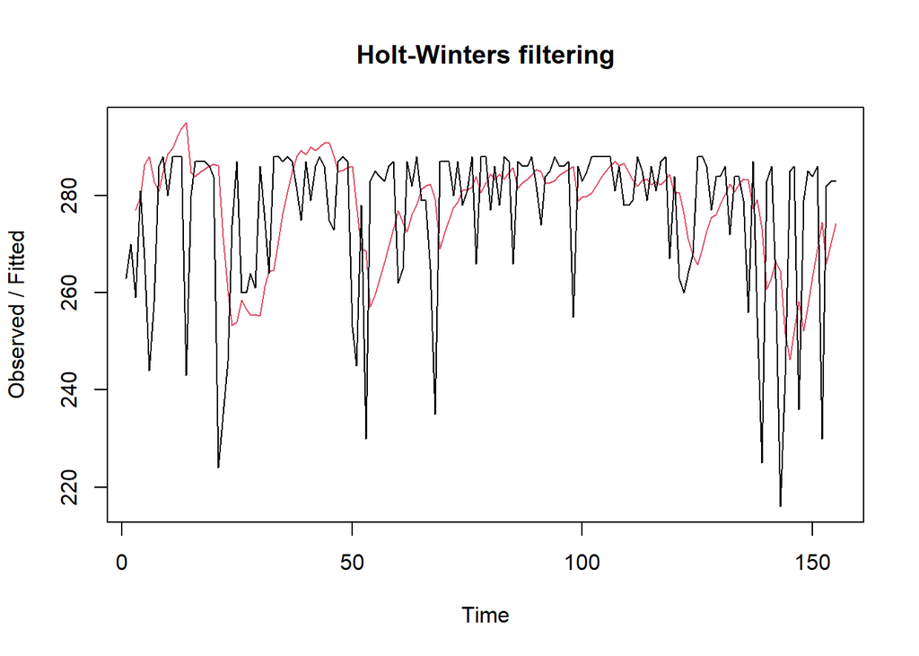

```r
#Lamda=0.2 dan gamma=0.2
des.1<- HoltWinters(train.ts, gamma = FALSE, beta = 0.2, alpha = 0.2)
plot(des.1)
```

```r
#ramalan
ramalandes1<- forecast(des.1, h=39)
ramalandes1
```

```
##     Point Forecast    Lo 80    Hi 80    Lo 95    Hi 95
## 156       277.8905 255.5611 300.2198 243.7407 312.0402
## 157       279.7689 256.8054 302.7323 244.6493 314.8884
## 158       281.6472 257.8479 305.4466 245.2493 318.0452
## 159       283.5256 258.6768 308.3745 245.5226 321.5286
## 160       285.4040 259.2873 311.5207 245.4619 325.3461
## 161       287.2824 259.6806 314.8842 245.0691 329.4957
## 162       289.1608 259.8625 318.4590 244.3529 333.9686
## 163       291.0391 259.8419 322.2363 243.3271 338.7511
## 164       292.9175 259.6296 326.2055 242.0080 343.8270
## 165       294.7959 259.2368 330.3550 240.4130 349.1788
## 166       296.6743 258.6750 334.6735 238.5595 354.7891
## 167       298.5527 257.9550 339.1503 236.4639 360.6414
## 168       300.4310 257.0868 343.7753 234.1418 366.7203
## 169       302.3094 256.0796 348.5392 231.6070 373.0118
```

[output cut: 25 more lines]

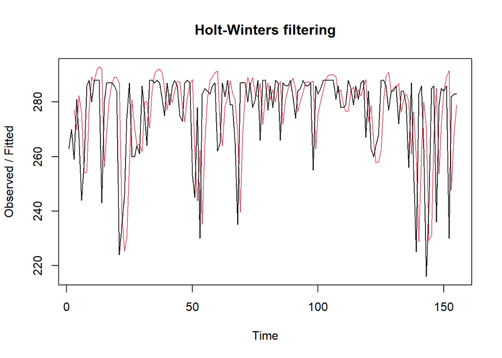

```r
#Lamda=0.6 dan gamma=0.3
des.2<- HoltWinters(train.ts, gamma = FALSE, beta = 0.3, alpha = 0.6)
plot(des.2)
```

```r
#ramalan
ramalandes2<- forecast(des.2, h=39)
ramalandes2
```

```
##     Point Forecast       Lo 80     Hi 80       Lo 95     Hi 95
## 156       284.2636  259.550591  308.9766  246.468319  322.0589
## 157       287.1141  255.772386  318.4558  239.181094  335.0471
## 158       289.9646  250.656142  329.2730  229.847514  350.0816
## 159       292.8151  244.453298  341.1768  218.852124  366.7780
## 160       295.6656  237.330314  354.0008  206.449501  384.8816
## 161       298.5160  229.399130  367.6330  192.810843  404.2213
## 162       301.3665  220.738509  381.9946  178.056607  424.6765
## 163       304.2170  211.406639  397.0274  162.275784  446.1583
## 164       307.0675  201.448431  412.6866  145.537059  468.5980
## 165       309.9180  190.899840  428.9362  127.895422  491.9406
## 166       312.7685  179.790522  445.7465  109.396228  516.1408
## 167       315.6190  168.145532  463.0925   90.077793  541.1602
## 168       318.4695  155.986451  480.9525   69.973124  566.9659
## 169       321.3200  143.332161  499.3078   49.111099  593.5289
```

[output cut: 25 more lines]

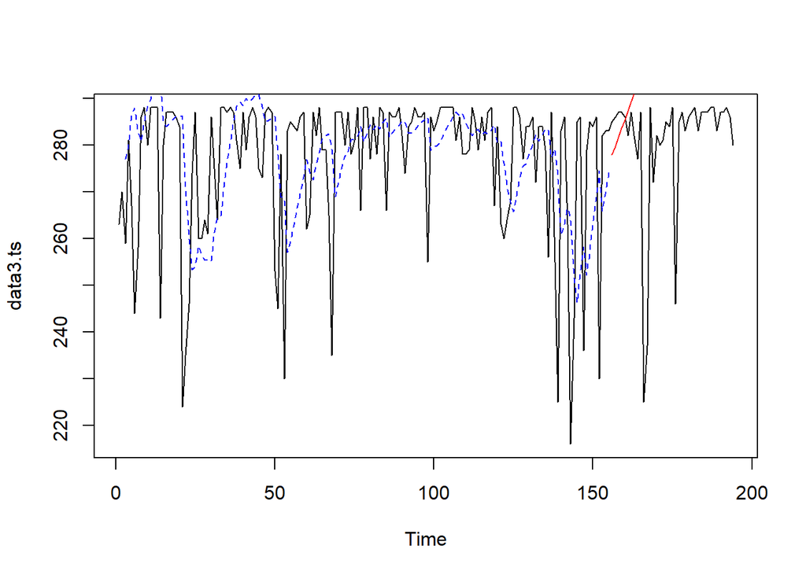

```r
plot(data3.ts)
lines(des.1$fitted[,1], lty=2, col="blue")
lines(ramalandes1$mean, col="red")
```

Untuk mendapatkan nilai parameter optimum dari DES, argumen `alpha` dan `beta` dapat dibuat `NULL` seperti berikut.

```r
#Lamda dan gamma optimum
des.opt<- HoltWinters(train.ts, gamma = FALSE)
des.opt
```

```
## Holt-Winters exponential smoothing with trend and without seasonal component.
##
## Call:
## HoltWinters(x = train.ts, gamma = FALSE)
##
## Smoothing parameters:
##  alpha: 0.3101942
##  beta : 0.09763307
##  gamma: FALSE
##
## Coefficients:
##          [,1]
## a 276.9572801
## b   0.8372259
```

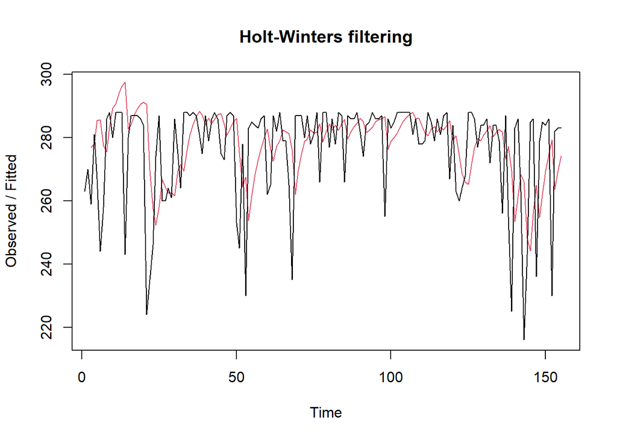

```r
plot(des.opt)
```

```r
#ramalan
ramalandesopt<- forecast(des.opt, h=39)
ramalandesopt
```

```
##     Point Forecast    Lo 80    Hi 80    Lo 95    Hi 95
## 156       277.7945 255.8624 299.7266 244.2523 311.3367
## 157       278.6317 255.4632 301.8002 243.1986 314.0649
## 158       279.4690 254.9149 304.0230 241.9168 317.0212
## 159       280.3062 254.2242 306.3882 240.4173 320.1951
## 160       281.1434 253.3988 308.8880 238.7117 323.5751
## 161       281.9806 252.4465 311.5147 236.8121 327.1492
## 162       282.8179 251.3750 314.2608 234.7301 330.9056
## 163       283.6551 250.1914 317.1188 232.4767 334.8334
## 164       284.4923 248.9024 320.0822 230.0623 338.9224
## 165       285.3295 247.5142 323.1449 227.4960 343.1631
## 166       286.1668 246.0323 326.3013 224.7864 347.5472
## 167       287.0040 244.4616 329.5464 221.9410 352.0670
## 168       287.8412 242.8065 332.8759 218.9666 356.7158
## 169       288.6784 241.0711 336.2858 215.8693 361.4875
```

[output cut: 25 more lines]

Selanjutnya akan dilakukan perhitungan akurasi pada data latih maupun data uji dengan ukuran akurasi SSE, MSE dan MAPE.

## Akurasi Data Latih

```r
#Akurasi Data Training
ssedes.train1<-des.1$SSE
msedes.train1<-ssedes.train1/length(train.ts)
sisaandes1<-ramalandes1$residuals
head(sisaandes1)
```

```
## Time Series:
## Start = 1
## End = 6
## Frequency = 1
## [1]        NA        NA -18.00000   1.32000 -19.27680 -43.98317
```

```r
mapedes.train1 <- sum(abs(sisaandes1[3:length(train.ts)]/train.ts[3:length(train.ts)])
                      *100)/length(train.ts)

akurasides.1 <- matrix(c(ssedes.train1,msedes.train1,mapedes.train1))
row.names(akurasides.1)<- c("SSE", "MSE", "MAPE")
colnames(akurasides.1) <- c("Akurasi lamda=0.2 dan gamma=0.2")
akurasides.1
```

```
##      Akurasi lamda=0.2 dan gamma=0.2
## SSE                     46251.960459
## MSE                       298.399745
## MAPE                        4.588006
```

```r
ssedes.train2<-des.2$SSE
msedes.train2<-ssedes.train2/length(train.ts)
sisaandes2<-ramalandes2$residuals
head(sisaandes2)
```

```
## Time Series:
## Start = 1
## End = 6
## Frequency = 1
## [1]        NA        NA -18.00000  11.04000 -15.33120 -32.12006
```

```r
mapedes.train2 <- sum(abs(sisaandes2[3:length(train.ts)]/train.ts[3:length(train.ts)])
                      *100)/length(train.ts)

akurasides.2 <- matrix(c(ssedes.train2,msedes.train2,mapedes.train2))
row.names(akurasides.2)<- c("SSE", "MSE", "MAPE")
colnames(akurasides.2) <- c("Akurasi lamda=0.6 dan gamma=0.3")
akurasides.2
```

```
##      Akurasi lamda=0.6 dan gamma=0.3
## SSE                     56526.102498
## MSE                       364.684532
## MAPE                        4.934553
```

## Akurasi Data Uji

```r
#Akurasi Data Testing
selisihdes1<-ramalandes1$mean-testing$Count
selisihdes1
```

```
## Time Series:
## Start = 156
## End = 194
## Frequency = 1
##  [1] -7.1095314 -6.2311497 -5.3527680 -3.4743864 -0.5960047  5.2823770
##  [7]  2.1607587  9.0391404 15.9175221  7.7959037 71.6742854 61.5526671
## [13] 12.4310488 30.3094305 22.1878122 26.0661938 26.9445755 24.8229572
## [19] 27.7013389 25.5797206 69.4581023 32.3364840 32.2148656 38.0932473
## [25] 36.9716290 37.8500107 38.7283924 45.6067741 43.4851557 45.3635374
## [31] 47.2419191 48.1203008 49.9986825 56.8770642 54.7554458 56.6338275
## [37] 57.5122092 61.3905909 69.2689726
```

```r
SSEtestingdes1<-sum(selisihdes1^2)
MSEtestingdes1<-SSEtestingdes1/length(testing$Count)
MAPEtestingdes1<-sum(abs(selisihdes1/testing$Count)*100)/length(testing$Count)

selisihdes2<-ramalandes2$mean-testing$Count
selisihdes2
```

```
## Time Series:
## Start = 156
## End = 194
## Frequency = 1
##  [1]  -0.7364089   1.1140829   2.9645746   5.8150664   9.6655581  16.5160499
##  [7]  14.3665416  22.2170334  30.0675251  22.9180169  87.7685086  78.6190004
## [13]  30.4694921  49.3199839  42.1704756  47.0209674  48.8714591  47.7219509
## [19]  51.5724426  50.4229344  95.2734261  59.1239179  59.9744096  66.8249013
## [25]  66.6753931  68.5258848  70.3763766  78.2268683  77.0773601  79.9278518
## [31]  82.7783436  84.6288353  87.4793271  95.3298188  94.1803106  97.0308023
## [37]  98.8812941 103.7317858 112.5822776
```

```r
SSEtestingdes2<-sum(selisihdes2^2)
MSEtestingdes2<-SSEtestingdes2/length(testing$Count)
MAPEtestingdes2<-sum(abs(selisihdes2/testing$Count)*100)/length(testing$Count)

selisihdesopt<-ramalandesopt$mean-testing$Count
selisihdesopt
```

```
## Time Series:
## Start = 156
## End = 194
## Frequency = 1
##  [1] -7.20549399 -7.36826806 -7.53104213 -6.69381620 -4.85659026 -0.01936433
##  [7] -4.18213840  1.65508753  7.49231346 -1.67046061 61.16676532 50.00399125
## [13] -0.15878282 16.67844311  7.51566904 10.35289497 10.19012090  7.02734683
## [19]  8.86457276  5.70179869 48.53902462 10.37625055  9.21347648 14.05070241
## [25] 11.88792834 11.72515427 11.56238020 17.39960613 14.23683206 15.07405800
## [31] 15.91128393 15.74850986 16.58573579 22.42296172 19.26018765 20.09741358
## [37] 19.93463951 22.77186544 29.60909137
```

```r
SSEtestingdesopt<-sum(selisihdesopt^2)
MSEtestingdesopt<-SSEtestingdesopt/length(testing$Count)
MAPEtestingdesopt<-sum(abs(selisihdesopt/testing$Count)*100)/length(testing$Count)

akurasitestingdes <-
  matrix(c(SSEtestingdes1,MSEtestingdes1,MAPEtestingdes1,SSEtestingdes2,MSEtestingdes2,
           MAPEtestingdes2,SSEtestingdesopt,MSEtestingdesopt,MAPEtestingdesopt),
         nrow=3,ncol=3)
row.names(akurasitestingdes)<- c("SSE", "MSE", "MAPE")
colnames(akurasitestingdes) <- c("des ske1","des ske2","des opt")
akurasitestingdes
```

```
##         des ske1     des ske2     des opt
## SSE  61543.22015 169072.69369 14996.15769
## MSE   1578.03129   4335.19727   384.51686
## MAPE    12.20935     20.63572     5.46552
```

# Perbandingan SES dan DES

```r
MSEfull <-
  matrix(c(MSEtesting1,MSEtesting2,MSEtestingopt,MSEtestingdes1,MSEtestingdes2,
           MSEtestingdesopt),nrow=3,ncol=2)
row.names(MSEfull)<- c("ske 1", "ske 2", "ske opt")
colnames(MSEfull) <- c("ses","des")
MSEfull
```

```
##              ses       des
## ske 1   237.2852 1578.0313
## ske 2   186.9116 4335.1973
## ske opt 275.1693  384.5169
```

# Perbandingan SMA, DMA, SES, DES

## Berdasarkan MSE

```r
perbandingan_akhir <- data.frame(
  Metode = c("SMA (m=4)", "DMA (m=4)",
             "SES (lamda=0.2)", "SES (lamda=0.7)", "SES (optimal)",
             "DES (ske1)", "DES (ske2)", "DES (optimal)"),
  MSE_Uji = c(MSE_test.sma, MSE_test.dma,
              MSEtesting1, MSEtesting2, MSEtestingopt,
              MSEtestingdes1, MSEtestingdes2, MSEtestingdesopt)
)

perbandingan_akhir[order(perbandingan_akhir$MSE_Uji), ]
```

```
##            Metode   MSE_Uji
## 4 SES (lamda=0.7)  186.9116
## 3 SES (lamda=0.2)  237.2852
## 5   SES (optimal)  275.1693
## 1       SMA (m=4)  319.5321
## 8   DES (optimal)  384.5169
## 2       DMA (m=4)  844.7916
## 6      DES (ske1) 1578.0313
## 7      DES (ske2) 4335.1973
```

# KESIMPULAN

Kesimpulan: Berdasarkan nilai MSE data uji, metode SES dengan $\lambda = 0,7$ merupakan metode terbaik karena menghasilkan nilai MSE paling kecil, yaitu 186,91, sehingga memiliki tingkat kesalahan peramalan paling rendah dibandingkan metode lainnya.